# PHYS 10791: Introduction to Data Science

[figure not shown]

**Course instructors:**

[Prof. Rene Breton](http://www.renebreton.org) - Twitter [@BretonRene](https://twitter.com/BretonRene)  
[Dr. Marco Gersabeck](http://www.hep.manchester.ac.uk/u/gersabec) - Twitter [@MarcoGersabeck](https://twitter.com/MarcoGersabeck)

Lecture 7 - 00:00

## 4.1 Bayesian inference and likelihood function

### 4.1.1 Recap and likelihood function

**Bayes' theorem**:

\begin{eqnarray} P(a \mid x) &=& \frac{I(a) \mathcal{L}(x \mid a)}{E(x)} \\ &=& \frac{I(a) \mathcal{L}(x \mid a)}{\sum_i I(a_i) \mathcal{L}(x \mid a_i)} = \frac{I(a) \mathcal{L}(x \mid a)}{\int_a I(a) \mathcal{L}(x \mid a) \, {\rm d}a} \end{eqnarray}

with:

- $x$: data
- $a$: parameter of the model
- $P$: posterior
- $I$: prior
- $L$: likelihood
- $E$: evidence

Knowing right hand side allows one to make inference on posterior probability, e.g., testing a hypothesis and fitting a model to data.

Consider multiple data points $x = \{x_i, x_2, \dots, x_N\}$ drawn from $\mathcal{L}(x_i \mid a)$ which depends on parameter $a$. Joint probability of data given the parameter is the product of probabilities:

\begin{eqnarray} \mathcal{L}(x \mid a) &=& \mathcal{L}(x_1 \mid a) \mathcal{L}(x_2 \mid a) \dots \mathcal{L}(x_N \mid a) \\ &=& \prod \mathcal{L}(x_i \mid a) \end{eqnarray}

Therefore:

\begin{equation} P(a \mid x) = \frac{I(a) \mathcal{L}(x \mid a)}{E(x)} = \frac{I(a) \prod \mathcal{L}(x_i \mid a)}{E(x)} \end{equation}

Lecture 7 - 00:10

### 4.1.2 Maximum a posteriori and maximum likelihood

Often difficult to know $E(x)$, but typically interested in relative value of $a$. Example: most likely outcome of $a$. We call it **maximum a posteriori (MAP)**.

MAP corresponds to $\widehat{a}_{\rm MAP}$ such that:

\begin{eqnarray} \widehat{a}_{\rm MAP} &=& \arg \max_{\substack a} P(a \mid x) &\equiv& \left. \frac{\partial P(a \mid x)}{\partial a} \right\rvert_{a = \widehat{a}} = 0\\ &=& \arg \max_{\substack a} \ln P(a \mid x) &\equiv& \left. \frac{\partial \ln P(a \mid x)}{\partial a} \right\rvert_{a = \widehat{a}} = 0 \,. \end{eqnarray}

Last line due to logarithms being a monotically increasing function of its argument. Using Bayes:

\begin{eqnarray} \ln P(a \mid x) &=& \ln \left( \frac{I(a) \prod \mathcal{L}(x_i \mid a)}{E(x)} \right) \\ &=& \ln I(a) + \ln \prod \mathcal{L}(x_i \mid a) - \ln E(x) \\ &=& \ln I(a) + \sum \ln \mathcal{L}(x_i \mid a) - \ln E(x) \,. \end{eqnarray}

Very important: easier to deal with summations than products (e.g. numerical precision of computations). Therefore:

\begin{eqnarray} \left. \frac{\partial \ln P(a \mid x)}{\partial a} \right\rvert_{a = \widehat{a}} = \left. \frac{\partial \ln I(a)}{\partial a} + \sum \frac{\partial \ln \mathcal{L}(x_i \mid a)}{\partial a} \right\rvert_{a = \widehat{a}} = 0 \,. \end{eqnarray}

Conclude: **for MAP the value of $E(x)$ is irrelevant**.

**The MAP of ($N$) multiple parameters is a set (of $N$) coupled differential equations to solve**.

#### Maximum likelihood estimation (MLE)

Case of prior $I(a)$ independent of $a$:

\begin{eqnarray} \left. \frac{\partial \ln P(a \mid x)}{\partial a} \right\rvert_{a = \widehat{a}} = \left. \sum \frac{\partial \ln \mathcal{L}(x_i \mid a)}{\partial a} \right\rvert_{a = \widehat{a}} = 0 \,. \end{eqnarray}

Called *flat priors*. Often the case if no reason to favour a value over another. MAP reduces to a **maximum likelihood estimation (MLE)**:

\begin{equation} \widehat{a}_{\rm MAP} = \arg \max_{\substack a} P(a \mid x) = \arg \max_{\substack a} \mathcal{L}(x \mid a) = \widehat{a}_{\rm MLE} \,. \end{equation}

Lecture 7 - 00:25

Example 1: maximum likelihood for a simple function

Consider data sample $x = \{0.89, 0.03, 0.50, 0.36, 0.49\}$ drawn from $\mathcal{L}(x_i \mid a) = 1 + a(x_i - 0.5)$, with $x_i \in [0,1]$. Let us calculate $\ln \mathcal{L}$:

\begin{eqnarray} \ln \mathcal{L} = \sum_i \ln \mathcal{L}(x \mid a=+1.0) &=& \ln 1.39 + \ln 0.53 + \ln 1.0 + \ln 0.86 + \ln 0.99 = -0.47 \\ \ln \mathcal{L} = \sum_i \ln \mathcal{L}(x \mid a=-1.0) &=& \ln 0.61 + \ln 1.47 + \ln 1.0 + \ln 1.14 + \ln 1.01 = 0.03 \\ \end{eqnarray}

Can try other values of $a$ and plot.

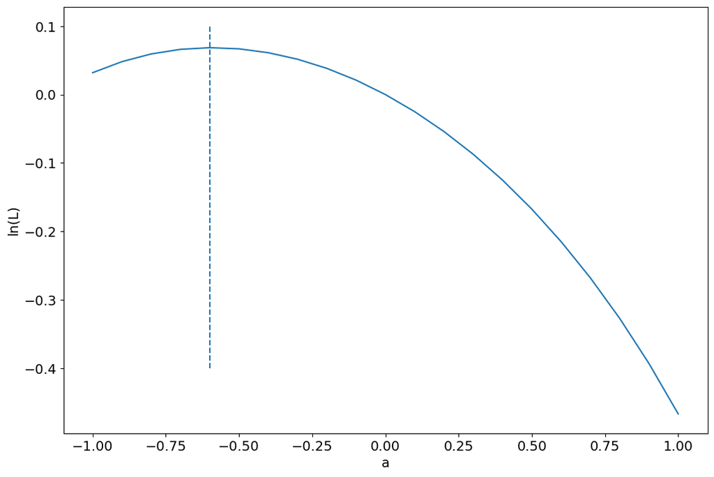

MLE for $\widehat{a} \approx -0.6$.

Lecture 7 - 00:30

Example 2: MLE of a simple lifetime

Study the decay of a radioactive nucleus. Probability of decay is:

\begin{equation} \mathcal{L}(t_i \mid \tau) = \frac{1}{\tau} e^{-t_i/\tau} \,, \end{equation}

where $\tau$ is lifetime. Imagine N events with decay times $\left\{t_i\right\}$. What is the most likely $\widehat{\tau}$?

\begin{eqnarray} \frac{\partial \ln \mathcal{L}}{\partial \tau} &=& \sum \frac{\partial}{\partial \tau} \ln{\left( \frac{1}{\tau} e^{-t_i/\tau} \right)} \\ &=& \sum \left( \frac{t_i}{\tau^2} - \frac{1}{\tau} \right) \,. \end{eqnarray}

Setting to zero and solving for $\tau$ gives MLE of $\widehat{\tau}$:

\begin{equation} \widehat{\tau} = \frac{1}{N} \sum t_i \,. \end{equation}

In this case MLE is sample mean, $\widehat{\tau} = \langle t \rangle$.

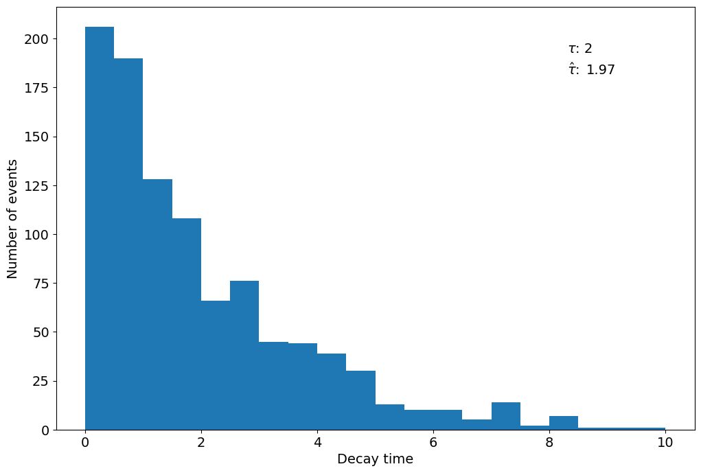

Lecture 7 - 00:40 - Problem Sheet 2, Problem 1 (Bayesian M&M candies)

Lecture 8 - 00:00

## 4.2 Maximum likelihood as an estimator

1. $\widehat{\mu}$ being equal to the sample mean suggests that the maximum likelihood is consistent
2. $\widehat{\sigma}$ being equal to the uncorrected standard deviation implies that the maximum likelihood is biased, but this vanishes in the limit of large $N$

Without going into the full details, we will state the following properties of MLEs [see Barlow, Chapter 5, for more details]:

> 1. Generally (though not strictly always) consistent
> 2. Generally biased, but this disappears in the limit of large $N$ for any consistent estimator
> 3. Generally invariant
> 4. Generally efficient

We therefore conclude that the MLE can be thought of as a good estimator in most cases. The invariance is in itself a very useful property.

Lecture 8 - 00:10

### 4.2.1 Maximum likelihood invariance

We have stated that the invariance of the MLE without any justification. Let us assume that instead of considering a specific parameter $a$ we are interested in a function of that parameter $f(a)$. The invariance tells us that:

It is possible to understand this principle by applying the chain rule:

\begin{equation} \left. \frac{\partial \mathcal{L}}{\partial a} \right\rvert_\widehat{a} = \left. \frac{\partial \mathcal{L}}{\partial f(a)} \frac{\partial f(a)}{\partial a} \right\rvert_\widehat{a} = 0 \,. \end{equation}

Therefore, this implies that $\partial \mathcal{L}/\partial f(a) = 0$, unless $\partial f(a)/\partial a = 0$. The latter would happend if $f(a)$ does not depend on $a$, but this would be a trivial case.

Lecture 8 - 00:15

### 4.2.2 Efficiency of the maximum likelihood

If we are interested to look at the efficiency of the maximum likelihood, we must consider the variance of a given estimator, $V(\widehat{a})$. It is in fact possible to derive a minimum bound, known as the **Rao-Cramér-Frechet (RCF) inequality** (also called **information inequality**):

\begin{equation} V(\widehat{a}) \ge \frac{\left( 1 + \frac{\partial b}{\partial a} \right)^2}{\left< -\frac{\partial^2 \ln \mathcal{L}}{\partial a^2} \right>} \,, \end{equation}

where $b \equiv \left<\widehat{a}\right> - a$ is the bias. (*It is beyond the scope of this course to derive the RCF inequality, but more information can be found in Barlow, Chapter 5, and Cowan, Chapter 6.*)

In the case of an unbiased estimator ($b = 0$), the RCF inequality becomes known as the **minimum variance bound (MVB)**:

\begin{equation} V(\widehat{a})_{\rm MVB} \ge \frac{1}{\left< -\frac{\partial^2 \ln \mathcal{L}}{\partial a^2} \right>} \,. \end{equation}

The denominator on the right-hand side is referred to as the **Fisher information**.

Lecture 8 - 00:20

### 4.2.3 Variance on maximum likelihood estimators

As we often do in physics, such as with the uncertainty principle in quantum mechanics, we usually approximate the variance from the above by dropping the inequality and assuming that the bias is negligible. Instead of averaging at the denominator, we just evaluate the Fisher information at the value of the estimator. Therefore \begin{equation} V(\widehat{a}) = \sigma^2_\widehat{a} = \left. \left( -\frac{\partial^2 \ln \mathcal{L}}{\partial a^2} \right)^{-1} \right\rvert_{a = \widehat{a}} \,. \end{equation}

**This gives us a simple way to calculate the uncertainty on the MLE estimator.**

If the MLE contains multiple parameters, the above equation can be generalised to a covariance matrix: \begin{equation} \mathbf{V}(\widehat{a}) = \left(-\mathbf{H}(\widehat{a})\right)^{-1} \,, \end{equation} with \begin{eqnarray} H_{ij} &=& \left. \frac{\partial^2 \ln \mathcal{L}}{\partial a_i \partial a_j} \right\rvert_\widehat{a} \\ &=& \begin{bmatrix} \frac{\partial^2 \ln \mathcal{L}}{\partial a_i^2} & \frac{\partial^2 \ln \mathcal{L}}{\partial a_i \partial a_j} & \dots \\ \frac{\partial^2 \ln \mathcal{L}}{\partial a_j \partial a_i} & \frac{\partial^2 \ln \mathcal{L}}{\partial a_j^2} & \dots \\ \vdots & \vdots & \ddots \\ \end{bmatrix}_{\widehat{a}} \,. \end{eqnarray}

In this case, $\mathbf{V}(\widehat{a})$ is the matrix inverse of the negative $\mathbf{H}(\widehat{a})$.

Note that if the matrix $\mathbf{H}(\widehat{a})$ is diagonal (i.e. the $i \neq j$ terms are all zero), then the $V_{ii}$ terms are the inverse of the $H_{ii}$ and the off-diagonal terms are zero.

One further way to understand the variance on MLE is to consider small variations around it. Let us expand the log-likelihod around the estimator using a Taylor series:

\begin{equation} \ln \mathcal{L}(a) = \ln \mathcal{L}(\widehat{a}) + \left. \frac{\partial \ln \mathcal{L}}{\partial a} \right\rvert_\widehat{a} (a - \widehat{a}) + \frac{1}{2} \left. \frac{\partial^2 \ln \mathcal{L}}{\partial a^2} \right\rvert_\widehat{a} (a - \widehat{a})^2 + \dots \,. \end{equation}

By definition of $\widehat{a}$, $\ln \mathcal{L}(\widehat{a}) = \ln \mathcal{L}_{\rm max}$ and the first derivative is equal to zero. If we express the second derivative in terms of $\widehat{\sigma^2}_\widehat{a}$, we find that to second order:

\begin{equation} \ln \mathcal{L}(a) \approx \ln \mathcal{L}_{\rm max} - \frac{(a - \widehat{a})^2}{2 \sigma^2_\widehat{a}} \,. \end{equation}

This is essentially the equation of a Gaussian with mean $\widehat{a}$ and standard deviation $\widehat{\sigma_\widehat{a}}$:

\begin{equation} \mathcal{L}(a) \approx \mathcal{L}_{\rm max} \exp\left(\frac{-(a - \widehat{a})^2}{2 \sigma^2_\widehat{a}}\right) \,. \end{equation}

Therefore:

\begin{equation} \ln \mathcal{L}(\widehat{a} \pm \sigma_\widehat{a}) = \ln \mathcal{L}_{\rm max} - \frac{1}{2} \,. \end{equation}

We should highlight the important implications of what we have just derived:

> 1. The log-likelihood near the MLE can be approximated with a parabola, which means that the likelihood itself is a Gaussian in the MLE region.
> 2. The standard deviation on the MLE can be found by finding the value of the parameter for which the likelihood change by $\frac{1}{2}$ with respect to the MLE.

Lecture 8 - 00:25

Example 1: variance of a simple lifetime

Recall the previous example in which we calculated the MLE of a simple lifetime experiment. The log-likelihood is given by:

\begin{equation} \ln \mathcal{L} = \sum \ln{\left( \frac{1}{\tau} e^{-t_i/\tau} \right)} \\ \end{equation}

Differentiative twice yields:

\begin{eqnarray} \frac{\partial^2 \ln \mathcal{L}}{\partial \tau^2} &=& \frac{N}{\tau^2} \left( 1 - \frac{2}{N \tau} \sum t_i \right) \\ &=& \frac{N}{\tau^2} \left( 1 - \frac{2\widehat{\tau}}{\tau} \right) \,. \end{eqnarray}

It is possible to show that $\widehat{\tau}$ is unbiased (i.e. $b = \langle\widehat{\tau}\rangle - \tau = 0$) so that the RCF inequality reduces to the MVB. We can therefore calculate the inequality:

\begin{eqnarray} V(\widehat{\tau}) &\ge& \frac{1}{\left< -\frac{N}{\tau^2} \left( 1 - \frac{2\widehat{\tau}}{\tau} \right) \right>} \\ &\ge& \frac{1}{-\frac{N}{\tau^2} \left( 1 - \frac{2\left<\widehat{\tau}\right>}{\tau} \right)} \\ &\ge& \frac{\tau^2}{N} \,, \end{eqnarray} where we have use the fact that $\widehat{\tau} = \tau$ in order to get to the last line.

In specific cases one can directly calculate the variance of the estimator. This is the case for this problem, and one finds that $V(\widehat{\tau}) = \frac{\tau^2}{N}$. This means that the MVB is in fact the variance itself, and thus the maximum likelihood is maximally efficient.

Lecture 8 - 00:35

Example 2: maximum likelihood for a simple function

Here we take again the earlier example of the maximum likelihood of a simple function and evaluate the uncertainty on the best-fit parameter by looking for the parameter value at which the log-likelihood decreases by $\frac{1}{2}$ with respect to the maximum value.

*Note: Sometimes, as is the case here, the log-likelihood function is not perfectly symmetrical. This means that the uncertainty needs to be evaluated for each side individually or otherwise approximated with a parabola if the problem was solved analytically.*

```
Optimization terminated successfully.
         Current function value: -0.068503
         Iterations: 10
         Function evaluations: 20
ln_L_max: 0.068503
a_max: -0.59162
sigma_a_left: 1.2844
sigma_a_right: 1.5456
```

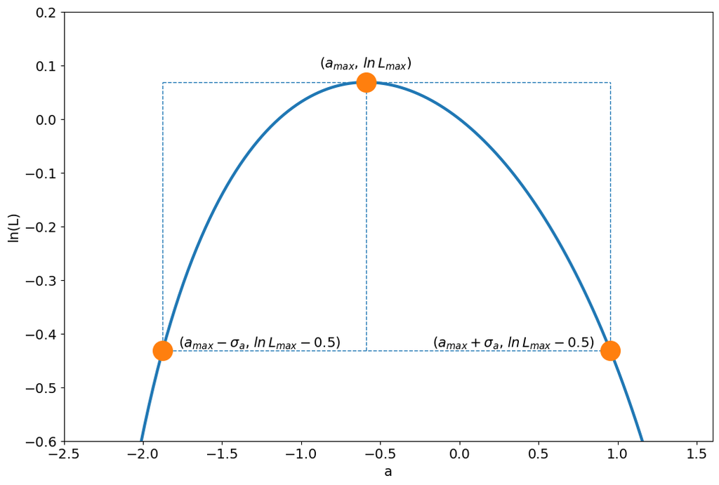

Lecture 8 - 00:40 - Problem Sheet 2, Problem 2 (MLE of a Gaussian...)

This work is licensed under a [Creative Commons Attribution-NonCommercial-ShareAlike 4.0 International License](http://creativecommons.org/licenses/by-nc-sa/4.0/)).

*Note: The content of this Jupyter Notebook is provided for educational purposes only.*